# R combined cycle power plant Project

Problem statement: The dataset contains 9568 data points collected from a Combined Cycle Power Plant over 6 years (2006-2011), when the power plant was set to work with full load. Features consist of hourly average ambient variables Temperature (T), Ambient Pressure (AP), Relative Humidity (RH) and Exhaust Vacuum (V) to predict the net hourly electrical energy output (EP) of the plant. A combined cycle power plant (CCPP) is composed of gas turbines (GT), steam turbines (ST) and heat recovery steam generators. In a CCPP, the electricity is generated by gas and steam turbines, which are combined in one cycle, and is transferred from one turbine to another. While the Vacuum is colected from and has effect on the Steam Turbine, he other three of the ambient variables effect the GT performance. For comparability with our baseline studies, and to allow 5x2 fold statistical tests be carried out, we provide the data shuffled five times. For each shuffling 2-fold CV is carried out and the resulting 10 measurements are used for statistical testing.

Loading all required library

```r
library(moments) #skewness
library(pastecs) #descriptive statistics stats.desc
library(diptest) # Hartigans' dip test for unimodality
library(fmsb) #VIF
library(DAAG) #K-fold validation
```

Data import Initial setwd command will set current working directory. The file in the format of csv(comma separated version) loaded to R in data.frame format. str command will give observation,data type, name, few sample of variables. colnames command will change column name.

Attribute Information:

Features consist of hourly average ambient variables - Temperature (T) in the range 1.81�C and 37.11�C, - Ambient Pressure (AP) in the range 992.89-1033.30 milibar, - Relative Humidity (RH) in the range 25.56% to 100.16% - Exhaust Vacuum (V) in teh range 25.36-81.56 cm Hg - Net hourly electrical energy output (EP) 420.26-495.76 MW The averages are taken from various sensors located around the plant that record the ambient variables every second. The variables are given without normalization.

```r
setwd("/home/sudhir/git/ML-R")
```

```
The working directory was changed to /home/sudhir/git/ML-R inside a notebook chunk. The working directory will be reset when the chunk is finished running. Use the knitr root.dir option in the setup chunk to change the the working directory for notebook chunks.
```

```r
data=read.csv("TED_OLS.csv",header=TRUE,na.string=c(" "))
str(data)
```

```
'data.frame':   9568 obs. of  5 variables:
 $ AT: num  14.96 25.18 5.11 20.86 10.82 ...
 $ EV: num  41.8 63 39.4 57.3 37.5 ...
 $ AP: num  1024 1020 1012 1010 1009 ...
 $ RH: num  73.2 59.1 92.1 76.6 96.6 ...
 $ E : num  463 444 489 446 474 ...
```

```r
colnames(data)=c("Temperature","Exhaustvacuum","Pressure","Relativehumidity","Energy")
str(data)
```

```
'data.frame':   9568 obs. of  5 variables:
 $ Temperature     : num  14.96 25.18 5.11 20.86 10.82 ...
 $ Exhaustvacuum   : num  41.8 63 39.4 57.3 37.5 ...
 $ Pressure        : num  1024 1020 1012 1010 1009 ...
 $ Relativehumidity: num  73.2 59.1 92.1 76.6 96.6 ...
 $ Energy          : num  463 444 489 446 474 ...
```

Finding missing value “NA” using “is.na()”.

```r
#missing value
summary(is.na(data)) #column wise summary
```

```
 Temperature     Exhaustvacuum    Pressure       Relativehumidity   Energy
 Mode :logical   Mode :logical   Mode :logical   Mode :logical    Mode :logical
 FALSE:9568      FALSE:9568      FALSE:9568      FALSE:9568       FALSE:9568
```

```r
table(is.na(data)) #Total summary
```

```
FALSE
47840
```

Measure of central tendency of data.

```r
summary(data)# M.o.CT
```

```
  Temperature    Exhaustvacuum      Pressure      Relativehumidity     Energy
 Min.   : 1.81   Min.   :25.36   Min.   : 992.9   Min.   : 25.56   Min.   :420.3
 1st Qu.:13.51   1st Qu.:41.74   1st Qu.:1009.1   1st Qu.: 63.33   1st Qu.:439.8
 Median :20.34   Median :52.08   Median :1012.9   Median : 74.97   Median :451.6
 Mean   :19.65   Mean   :54.31   Mean   :1013.3   Mean   : 73.31   Mean   :454.4
 3rd Qu.:25.72   3rd Qu.:66.54   3rd Qu.:1017.3   3rd Qu.: 84.83   3rd Qu.:468.4
 Max.   :37.11   Max.   :81.56   Max.   :1033.3   Max.   :100.16   Max.   :495.8
```

```r
stat.desc(data)# M.o.CT +M.o.V
```

|  | Temperature | Exhaustvacuum | Pressure | Relativehumidity | Energy |
| --- | --- | --- | --- | --- | --- |
| nbr.val | 9.57e+03 | 9.57e+03 | 9.57e+03 | 9.57e+03 | 9.57e+03 |
| nbr.null | 0.00e+00 | 0.00e+00 | 0.00e+00 | 0.00e+00 | 0.00e+00 |
| nbr.na | 0.00e+00 | 0.00e+00 | 0.00e+00 | 0.00e+00 | 0.00e+00 |
| min | 1.81e+00 | 2.54e+01 | 9.93e+02 | 2.56e+01 | 4.20e+02 |
| max | 3.71e+01 | 8.16e+01 | 1.03e+03 | 1.00e+02 | 4.96e+02 |
| range | 3.53e+01 | 5.62e+01 | 4.04e+01 | 7.46e+01 | 7.55e+01 |
| sum | 1.88e+05 | 5.20e+05 | 9.69e+06 | 7.01e+05 | 4.35e+06 |
| median | 2.03e+01 | 5.21e+01 | 1.01e+03 | 7.50e+01 | 4.52e+02 |
| mean | 1.97e+01 | 5.43e+01 | 1.01e+03 | 7.33e+01 | 4.54e+02 |
| SE.mean | 7.62e-02 | 1.30e-01 | 6.07e-02 | 1.49e-01 | 1.74e-01 |

[output cut: 4 more lines]

A boxplot provides a graphical view of the median, quartiles, maximum, and minimum of a data set. Outlier is an observation point that is distant from other observations.

A histogram is a graphical representation of the distribution of numerical data. It is an estimate of the probability distribution of a continuous variable.To contruct histogram,the first step is to “bin” the range of values—that is, divide the entire range of values into a series of intervals—and then count how many values fall into each interval.

plot(density(data$…) will give distribution of data

Univariate analysis of “Temperature” attribute

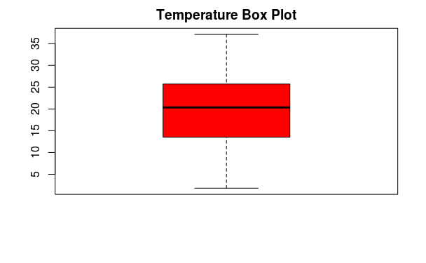

```r
boxplot(data$Temperature,main="Temperature Box Plot",col="red")
```

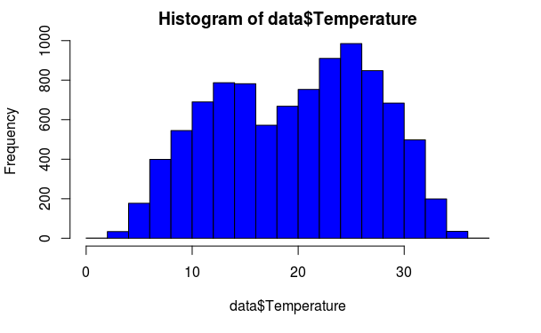

```r
hist(data$Temperature,col="blue")
```

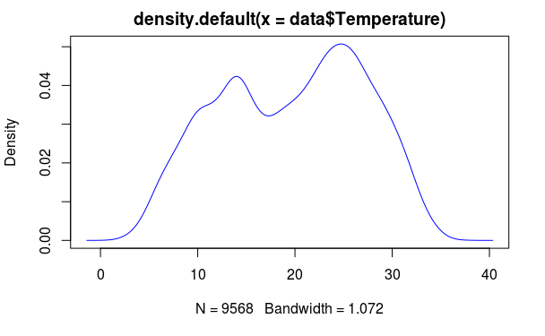

```r
plot(density(data$Temperature),col="blue")
```

```r
skewness(data$Temperature)
```

```
[1] -0.1363503
```

```r
dip.test(data$Temperature)
```

```
    Hartigans' dip test for unimodality / multimodality

data:  data$Temperature
D = 0.010076, p-value < 2.2e-16
alternative hypothesis: non-unimodal, i.e., at least bimodal
```

Univariate analysis of “Exhaust vacuum” attribute

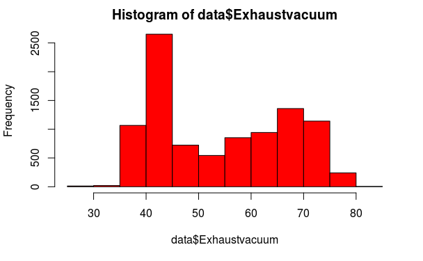

```r
hist(data$Exhaustvacuum,col="red")
```

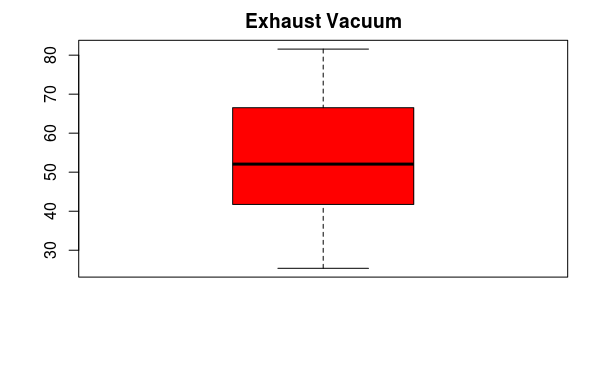

```r
boxplot(data$Exhaustvacuum,main="Exhaust Vacuum",col="red")
```

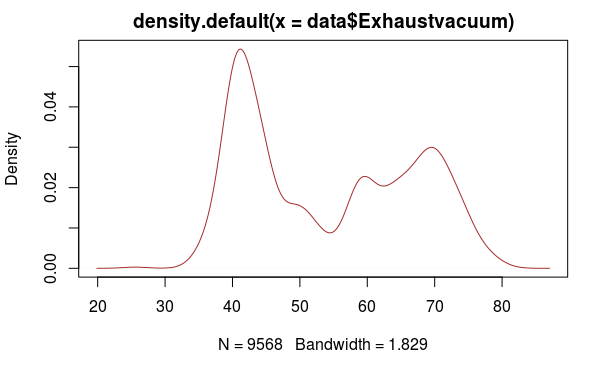

```r
plot(density(data$Exhaustvacuum),col='brown')
```

```r
skewness(data$Exhaustvacuum)
```

```
[1] 0.1984588
```

```r
dip.test(data$Exhaustvacuum)
```

```
    Hartigans' dip test for unimodality / multimodality

data:  data$Exhaustvacuum
D = 0.050073, p-value < 2.2e-16
alternative hypothesis: non-unimodal, i.e., at least bimodal
```

Univariate analysis of “Pressure” attribute

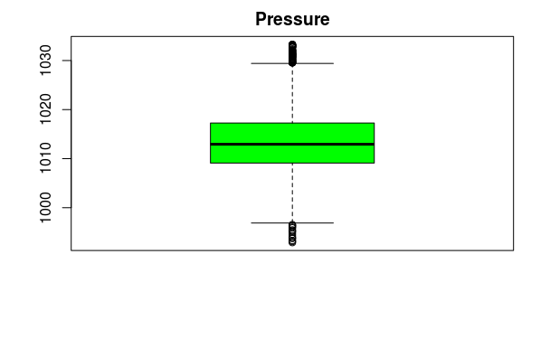

```r
boxplot(data$Pressure,main="Pressure",col="green")
```

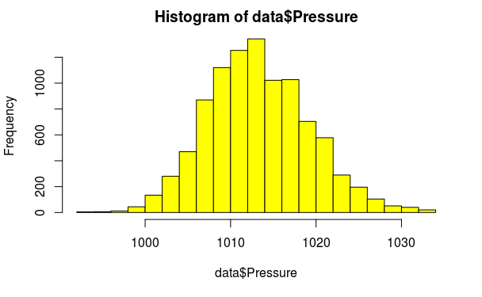

```r
hist(data$Pressure,col="yellow")
```

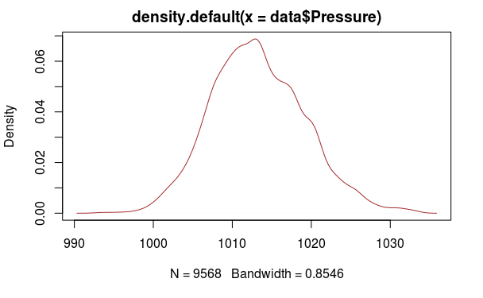

```r
plot(density(data$Pressure),col='brown')
```

```r
skewness(data$Pressure)
```

```
[1] 0.2653615
```

```r
dip.test(data$Pressure)
```

```
    Hartigans' dip test for unimodality / multimodality

data:  data$Pressure
D = 0.0038278, p-value = 0.5114
alternative hypothesis: non-unimodal, i.e., at least bimodal
```

Univariate analysis of “Energy” attribute

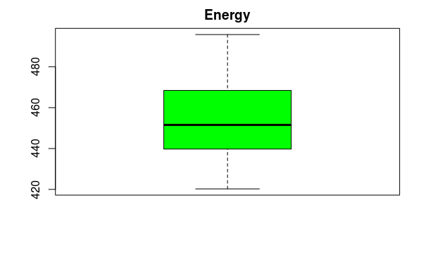

```r
boxplot(data$Energy,main="Energy",col="green")
```

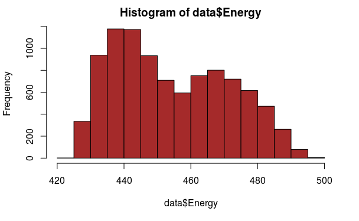

```r
hist(data$Energy,col="brown")
```

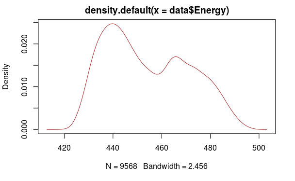

```r
plot(density(data$Energy),col='brown')
```

```r
skewness(data$Energy)
```

```
[1] 0.3064133
```

```r
dip.test(data$Energy)
```

```
    Hartigans' dip test for unimodality / multimodality

data:  data$Energy
D = 0.00969, p-value = 2.295e-06
alternative hypothesis: non-unimodal, i.e., at least bimodal
```

When data is not normally distributed, the cause for non-normality should be determined and appropriate remedial actions should be taken.Box cox transformation that may help to make data normal.

```r
c <- caret::BoxCoxTrans(data$Energy)
print(c)
```

```
Box-Cox Transformation

9568 data points used to estimate Lambda

Input data summary:
   Min. 1st Qu.  Median    Mean 3rd Qu.    Max.
  420.3   439.8   451.6   454.4   468.4   495.8

Largest/Smallest: 1.18
Sample Skewness: 0.306

Estimated Lambda: -2
```

```r
data$newen=data$Energy^(-2)
```

Bivariate analysis The covariance matrix generalizes the notion of variance to multiple dimensions. A scatter plot provides a graphical view of the relationship between two sets of attributes.

```r
#Co-relation between IV and DV
cor(data)
```

```
                 Temperature Exhaustvacuum    Pressure Relativehumidity     Energy
Temperature        1.0000000     0.8441067 -0.50754934      -0.54253465 -0.9481285
Exhaustvacuum      0.8441067     1.0000000 -0.41350216      -0.31218728 -0.8697803
Pressure          -0.5075493    -0.4135022  1.00000000       0.09957432  0.5184290
Relativehumidity  -0.5425347    -0.3121873  0.09957432       1.00000000  0.3897941
Energy            -0.9481285    -0.8697803  0.51842903       0.38979410  1.0000000
newen              0.9476248     0.8772094 -0.52341695      -0.39206893 -0.9986708
                      newen
Temperature       0.9476248
Exhaustvacuum     0.8772094
Pressure         -0.5234169
Relativehumidity -0.3920689
Energy           -0.9986708
newen             1.0000000
```

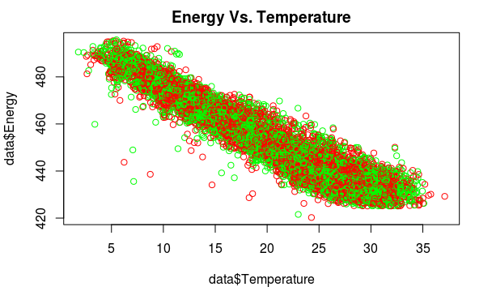

```r
plot(data$Temperature,data$Energy,col=c("green","red"),main="Energy Vs. Temperature",font=10)
```

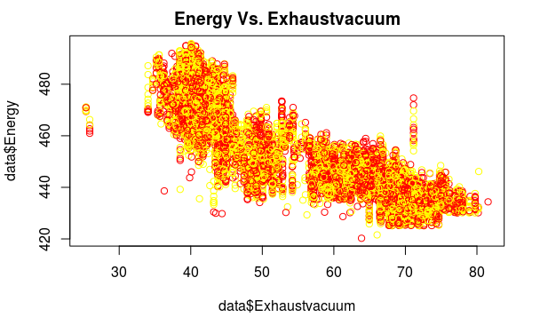

```r
plot(data$Exhaustvacuum,data$Energy,col=c("yellow","red"),main="Energy Vs. Exhaustvacuum",font=10)
```

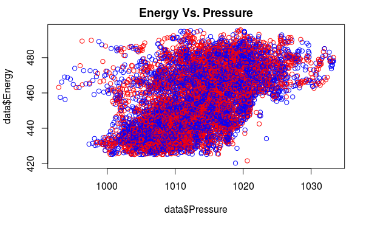

```r
plot(data$Pressure,data$Energy,col=c("red","blue"),main="Energy Vs. Pressure",font=10)
```

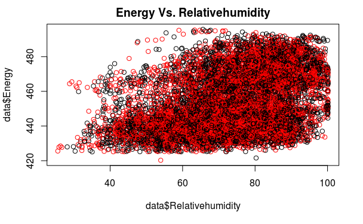

```r
plot(data$Relativehumidity,data$Energy,col=c("black","red"),main="Energy Vs. Relativehumidity",font=10)
```

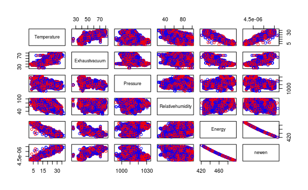

```r
pairs(data,col=c('red','blue'))
```

Sampling of data

```r
#cross validation
a=sample(nrow(data),nrow(data)*0.7)
train=data[a,]
test=data[-a,]
```

Data modeling lm function will give linear regression VIF is variance inflation factor

```r
#Model run/VIF check
model1=lm(Energy~.,data=train[,-6])
summary(model1)
```

```
Call:
lm(formula = Energy ~ ., data = train[, -6])

Residuals:
    Min      1Q  Median      3Q     Max
-43.147  -3.157  -0.101   3.202  17.592

Coefficients:
                   Estimate Std. Error t value Pr(>|t|)
(Intercept)      448.296890  11.549661   38.81  < 2e-16 ***
Temperature       -1.986797   0.017969 -110.57  < 2e-16 ***
Exhaustvacuum     -0.231010   0.008528  -27.09  < 2e-16 ***
Pressure           0.068234   0.011204    6.09 1.19e-09 ***
Relativehumidity  -0.156850   0.004928  -31.83  < 2e-16 ***
---
Signif. codes:  0 ‘***’ 0.001 ‘**’ 0.01 ‘*’ 0.05 ‘.’ 0.1 ‘ ’ 1

Residual standard error: 4.494 on 6692 degrees of freedom
Multiple R-squared:  0.931, Adjusted R-squared:  0.9309
F-statistic: 2.256e+04 on 4 and 6692 DF,  p-value: < 2.2e-16
```

```r
VIF(model1)
```

```
[1] 14.48468
```

```r
model2=lm(Energy~Pressure+Relativehumidity+Exhaustvacuum,data=train)
summary(model2)
```

```
Call:
lm(formula = Energy ~ Pressure + Relativehumidity + Exhaustvacuum,
    data = train)

Residuals:
    Min      1Q  Median      3Q     Max
-37.722  -5.043  -0.172   4.515  31.903

Coefficients:
                   Estimate Std. Error  t value Pr(>|t|)
(Intercept)      -91.925466  17.594046   -5.225  1.8e-07 ***
Pressure           0.580458   0.017150   33.846  < 2e-16 ***
Relativehumidity   0.167015   0.006662   25.069  < 2e-16 ***
Exhaustvacuum     -0.996645   0.008368 -119.107  < 2e-16 ***
---
Signif. codes:  0 ‘***’ 0.001 ‘**’ 0.01 ‘*’ 0.05 ‘.’ 0.1 ‘ ’ 1

Residual standard error: 7.556 on 6693 degrees of freedom
Multiple R-squared:  0.8048,    Adjusted R-squared:  0.8048
F-statistic:  9201 on 3 and 6693 DF,  p-value: < 2.2e-16
```

```r
VIF(model2)
```

```
[1] 5.124063
```

```r
model3=lm(newen~.,data=train[,-5])
summary(model1)
```

```
Call:
lm(formula = Energy ~ ., data = train[, -6])

Residuals:
    Min      1Q  Median      3Q     Max
-43.147  -3.157  -0.101   3.202  17.592

Coefficients:
                   Estimate Std. Error t value Pr(>|t|)
(Intercept)      448.296890  11.549661   38.81  < 2e-16 ***
Temperature       -1.986797   0.017969 -110.57  < 2e-16 ***
Exhaustvacuum     -0.231010   0.008528  -27.09  < 2e-16 ***
Pressure           0.068234   0.011204    6.09 1.19e-09 ***
Relativehumidity  -0.156850   0.004928  -31.83  < 2e-16 ***
---
Signif. codes:  0 ‘***’ 0.001 ‘**’ 0.01 ‘*’ 0.05 ‘.’ 0.1 ‘ ’ 1

Residual standard error: 4.494 on 6692 degrees of freedom
Multiple R-squared:  0.931, Adjusted R-squared:  0.9309
F-statistic: 2.256e+04 on 4 and 6692 DF,  p-value: < 2.2e-16
```

```r
VIF(model1)
```

```
[1] 14.48468
```

```r
model=lm(newen~Pressure+Relativehumidity+Exhaustvacuum,data=train[,-5])
summary(model)
```

```
Call:
lm(formula = newen ~ Pressure + Relativehumidity + Exhaustvacuum,
    data = train[, -5])

Residuals:
       Min         1Q     Median         3Q        Max
-6.726e-07 -9.747e-08  1.880e-09  1.046e-07  8.088e-07

Coefficients:
                   Estimate Std. Error t value Pr(>|t|)
(Intercept)       1.654e-05  3.578e-07   46.23   <2e-16 ***
Pressure         -1.241e-08  3.488e-10  -35.57   <2e-16 ***
Relativehumidity -3.530e-09  1.355e-10  -26.05   <2e-16 ***
Exhaustvacuum     2.119e-08  1.702e-10  124.54   <2e-16 ***
---
Signif. codes:  0 ‘***’ 0.001 ‘**’ 0.01 ‘*’ 0.05 ‘.’ 0.1 ‘ ’ 1

Residual standard error: 1.537e-07 on 6693 degrees of freedom
Multiple R-squared:  0.8185,    Adjusted R-squared:  0.8185
F-statistic: 1.006e+04 on 3 and 6693 DF,  p-value: < 2.2e-16
```

```r
VIF(model)
```

```
[1] 5.510745
```

Model validation R^2 will determine performation of model in predicted value.

```r
# Model validation in test
test=test[,-5]
pred=predict(model,test)
SSE <- sum((test$newen - pred) ^ 2)
SST <- sum((test$newen - mean(test$newen)) ^ 2)
rsquare=1 - SSE/SST
rsquare
```

```
[1] 0.8154671
```

```r
test$pred=pred
rmse=(mean((test$Energy-test$pred)^2))^0.5
rmseTrain=(mean((train$Energy-model$fitted.values)^2))^0.5
```

Model assumption

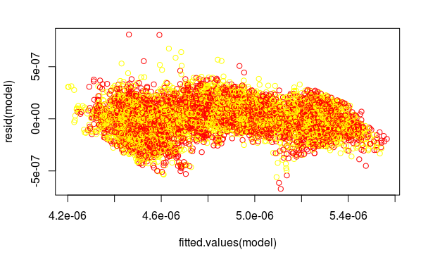

```r
#Model Assumption Testing
plot(fitted.values(model),resid(model),col=c("red","yellow"))#homoscedasticity
```

```r
#Breusch-Pagan test for homoscedasticity
library(lmtest)
lmtest::bptest(model)
```

```
    studentized Breusch-Pagan test

data:  model
BP = 285.84, df = 3, p-value < 2.2e-16
```

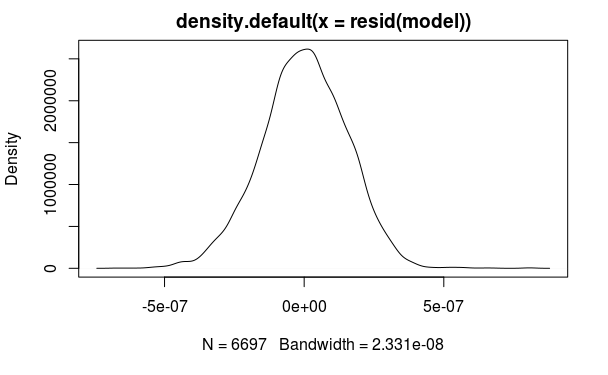

```r
plot(density(resid(model)))#normality
```

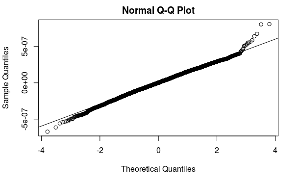

```r
qqnorm(resid(model))
qqline(resid(model))
```

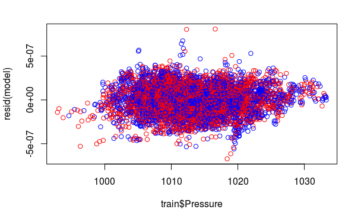

```r
plot(train$Pressure,resid(model),col=c("red","blue"))#Linearity
```

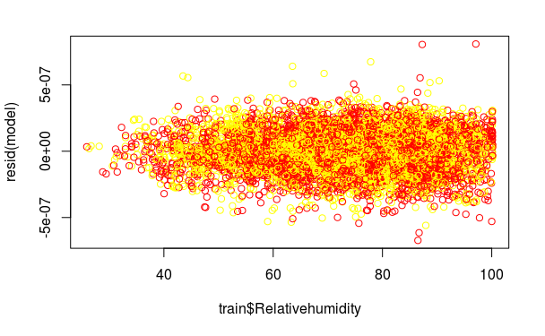

```r
plot(train$Relativehumidity,resid(model),col=c("red","yellow"))#Linearity
```

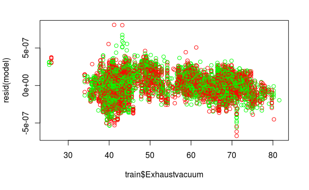

```r
plot(train$Exhaustvacuum,resid(model),col=c("red","green"))#Linearity
```

```
Analysis of Variance Table

Response: Energy
                   Df  Sum Sq Mean Sq F value Pr(>F)
Pressure            1  748977  748977   13112 <2e-16 ***
Relativehumidity    1  321879  321879    5635 <2e-16 ***
Exhaustvacuum       1 1169533 1169533   20474 <2e-16 ***
Residuals        9564  546309      57
---
Signif. codes:  0 ‘***’ 0.001 ‘**’ 0.01 ‘*’ 0.05 ‘.’ 0.1 ‘ ’ 1
```

```
 As there is >1 explanatory variable, cross-validation
 predicted values for a fold are not a linear function
 of corresponding overall predicted values.  Lines that
 are shown for the different folds are approximate
```

[output not shown]

[output cut: 969 more lines]

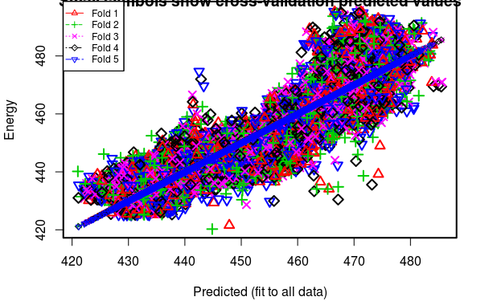

```r
# Model validation
res = cv.lm(data=data, (form.lm =Energy~Pressure+Relativehumidity+Exhaustvacuum),m=5,dots=FALSE,seed=29, plotit = c("Observed", "Residual"), legend.pos="topleft")
```

K fold summary

```r
#k fold summary
k=5
data$id <- sample(1:k, nrow(data), replace = TRUE)
list <- 1:k
for(i in 1:k){
  trainset <- subset(data,id %in% list[-i])
  testset <- subset(data,id %in% c(i))
  model <- lm(trainset$Energy~trainset$Pressure+trainset$Exhaustvacuum+trainset$Relativehumidity)
  predictions <- predict(model,testset[-c(4,5)])
  a <- summary(model)
   rmse <- sqrt(mean(model$residuals^2))
   print(model$coefficients)
   print(a$r.squared)
   print(rmse)
 }
```

```
'newdata' had 1925 rows but variables found have 7643 rows
```

```
              (Intercept)         trainset$Pressure    trainset$Exhaustvacuum
                  -64.220                     0.554                    -1.004
trainset$Relativehumidity
                    0.162
[1] 0.803
[1] 7.59
```

```
'newdata' had 1921 rows but variables found have 7647 rows
```

```
              (Intercept)         trainset$Pressure    trainset$Exhaustvacuum
                  -65.708                     0.555                    -1.008
trainset$Relativehumidity
                    0.168
[1] 0.803
[1] 7.59
```

```
'newdata' had 1947 rows but variables found have 7621 rows
```

```
              (Intercept)         trainset$Pressure    trainset$Exhaustvacuum
                  -70.690                     0.560                    -1.002
trainset$Relativehumidity
                    0.159
[1] 0.805
[1] 7.51
```

```
'newdata' had 1845 rows but variables found have 7723 rows
```

```
              (Intercept)         trainset$Pressure    trainset$Exhaustvacuum
                  -80.940                     0.571                    -0.998
trainset$Relativehumidity
                    0.154
[1] 0.803
[1] 7.58
```

```
'newdata' had 1930 rows but variables found have 7638 rows
```

```
              (Intercept)         trainset$Pressure    trainset$Exhaustvacuum
                  -93.612                     0.583                    -0.996
trainset$Relativehumidity
                    0.161
[1] 0.806
[1] 7.52
```

```r
# #Actual Vs. Fitted value
plot(fitted.values(model),data$Energy,col=c("red","blue"),main="Actual value vs. Fitted value")#Actual Vs. fitted
```

```
Error in xy.coords(x, y, xlabel, ylabel, log) :
  'x' and 'y' lengths differ
```